# Node analysis of social connectedness and health inequalities

Following up on our discussion last week, we now look at five things specifically:

1. Reduce multicollinearity by using just one SCI variable and no interactions
2. Adding countries not as random, but fixed effects
3. Consider moving to multi-level modelling
4. Avoid overfitting by using the HDI as the only control (besides SCI and countries)
5. Focus on outcomes related to sexual and reproductive health. This means dropping child vaccination outcomes and adding outcomes on knowledge and behaviour related to HIV and FGM

### Relevant libraries

```r
library(tidyverse)    # Data wrangling
library(sf)           # Spatial analysis
library(caret)        # For machine learning and preprocessing
library(spdep)        # For spatial analysis
library(spatialreg)   # For spatial regressions
library(olsrr)        # For OLS residual diagnostics
library(lme4)         # For random effects models
library(lmerTest)     # For approximated p-values in mixed models
library(ggplot2)      # Visualizations
library(broom)        # For data.frame-like summary outputs

library(sjPlot)       # for tab_model function

select <- dplyr::select
```

### Relevant data

```r
# Map data
afr_dat <- st_read(dsn = "/Users/tillkoebe/Documents/GitHub/health_inequalities/combined_dataset/GADM_1_geometries.gpkg") %>%
  st_make_valid() %>%
  st_transform(4326)
# Social Connectedness Index
sci <- read.csv("/Users/tillkoebe/Documents/GitHub/health_inequalities/external_dataset/sci_indices.csv") %>%
  distinct(user_loc, .keep_all = T)

# Worldpop covariates
wp <- read.csv("/Users/tillkoebe/Documents/GitHub/health_inequalities/external_dataset/wp.csv") %>%
  distinct(GID_1, .keep_all = T)

# Human Development Index
hdi <- read.csv("/Users/tillkoebe/Documents/GitHub/health_inequalities/external_dataset/hdi.csv") %>%
  distinct(GID_1, .keep_all = T)

# Facebook covariates
fb <- read.csv("/Users/tillkoebe/Documents/GitHub/health_inequalities/external_dataset/fb.csv") %>%
  distinct(GID_1, .keep_all = T)

# DHS data
dhs <- read.csv('/Users/tillkoebe/Documents/GitHub/health_inequalities/external_dataset/dhs_health.csv')

# Afrobarometer
afr <- read.csv('/Users/tillkoebe/Documents/GitHub/health_inequalities/external_dataset/afrobarometer.csv') %>%
  distinct(GID_1, .keep_all = T)
```

### Defining targets and controls

Let’s define our targets and controls:

```r
### Define targets
dhs_targets <- dhs %>%
  select(rh_anc_pv:we_num_justifydv) %>%
  select(starts_with(c('rh', 'fp', 'hk', 'fg'))) %>%
  select(-fp_message_noneof4, -hk_sexprtnr_num, -hk_cond_notprtnr) %>% #excluded as they either reduce sample size or they are out of the 0-1 range
  names()

### Define controls
dhs_controls <- c(
  'poorest',
  'poorer',
  'middle',
  'richer',
  'richest',
  'female',
  'secondary_or_higher',
  'has_mobile_phone_yes',
  'rural',
  "X.0.15.",
  "X.15.20.",
  "X.20.25.",
  "X.25.30.",
  "X.30.35.",
  "X.35.40.",
  "X.40.45.",
  "X.45.50.",
  "X.50.inf."
)

sci_controls <- c('Mean_dist_to_SCI_km', # Average distance of friendships
                  'Median_dist_to_SCI_km', # Average distance of friendships
                  'Std_dist_to_SCI_km', # Clustering measure of friendships across distances
                  'Total_dist_to_SCI_km', # Total distance of friendships
                  'Ratio_selfloop_to_country', # Share of local friendships within the same country
                  'Ratio_selfloop_to_africa', # Share of local friendships that stay within Africa
                  'Ratio_selfloop_to_all_sci', # Share of local friendships of all friendships
                  'Average_distance_of_friendships_km',
                  'Mean_SCI_without_Self', # Average probability of friendships with other regions
                  'Median_SCI_without_Self', # Average probability of friendships with other regions
                  'Std_SCI_without_Self', # Clustering measure for the probability of friendships with other regions
                  'Mean_SCI_with_Self', # Average probability of friendships across all regions
                  'Median_SCI_with_Self', # Average probability of friendships across all regions
                  'Std_SCI_with_Self', # Average probability of friendships across all regions
                  'Mean_friendship', # Average friendships per FB users
                  'Median_friendship', # Average friendships per FB users
                  'Std_friendship', # Clustering measure for friendships per FB user
                  'Total_friendship', # Sum of friendships per FB user
                  'Ratio_SCI_low_hi_africa', # Share of friendships to regions with a low health index
                  'Ratio_SCI_middle_hi_africa', # Share of friendships to regions with a medium health index
                  'Ratio_SCI_high_hi_africa' # Share of friendships to regions with a high health index
)

hdi_controls <- c('HDI')

wp_controls <- c(
  'Mean_of_Night_Light',
  'Std_of_Night_Light',
  'Mean_distance_to_major_rd_intersection',
  'Std_distance_to_major_rd_intersection',
  'Mean_distance_to_major_rd',
  'Std_distance_to_major_rd',
  "Mean_distance_to_inland_water",
  "Std_distance_to_inland_water",
  "Mean_built_settlement_growth",
  "Std_built_settlement_growth")

fb_controls <- c('fb_rwi_mean',
                 'fb_rwi_mean_pop_wght',
                 'FB_pntr_15to49_female',
                 'FB_pntr_15to49_all')

afr_controls <- c('member_community',
                  'trpar',
                  'trtax',
                  'trgov',
                  'trlaw',
                  'trgen',
                  'trrel',
                  'trnei',
                  'tracq',
                  'railway_contact',
                  'explorer_contact',
                  'district_ethnic_frac',
                  'loc_ln_export_area')
```

We then merge datasets and create the country dummy:

```r
dat <- dhs %>%
  select(GID_1,
         all_of(dhs_targets),
         all_of(dhs_controls)) %>%
  left_join(sci %>%
              select(GID_1 = user_loc,
                     all_of(sci_controls)),
            by = 'GID_1') %>%
  left_join(hdi %>%
              select(GID_1,
                     all_of(hdi_controls)),
            by = 'GID_1') %>%
  left_join(wp %>%
              drop_na(GID_1) %>%
              select(GID_1,
                     all_of(wp_controls)),
            by = 'GID_1') %>%
  left_join(fb %>%
              select(GID_1,
                     all_of(fb_controls)),
            by = 'GID_1') %>%
  left_join(afr %>%
              select(GID_1,
                     all_of(afr_controls)),
            by = 'GID_1') %>%
  mutate(iso3 = substr(GID_1, 1, 3))
```

Here an overview of the variables we now have in our dataset:

```r
dim(dat)
```

```
## [1] 483 102
```

```r
names(dat)
```

```
##   [1] "GID_1"
##   [2] "rh_anc_pv"
##   [3] "rh_anc_pvskill"
##   [4] "rh_anc_numvs"
##   [5] "rh_anc_4vs"
##   [6] "rh_anc_moprg"
##   [7] "rh_prob_permit"
##   [8] "rh_prob_money"
##   [9] "rh_prob_dist"
##  [10] "rh_prob_alone"
##  [11] "rh_prob_minone"
##  [12] "fp_know_any"
##  [13] "fp_know_mod"
##  [14] "fp_know_trad"
##  [15] "fp_message_noneof3"
```

[output cut: 87 more lines]

A description of the variables can be found [here](https://drive.google.com/file/d/1vCgciS4_zMz6hs5SoRl8_5yxP5drHt1C/view?usp=sharing).

### Summary statistics

```r
dat %>%
  select(all_of(dhs_targets)) %>%
  summary()
```

```
##    rh_anc_pv      rh_anc_pvskill      rh_anc_numvs      rh_anc_4vs
##  Min.   :0.2969   Min.   :0.005495   Min.   :0.6043   Min.   :0.1260
##  1st Qu.:0.8834   1st Qu.:0.475129   1st Qu.:0.9468   1st Qu.:0.4337
##  Median :0.9627   Median :0.886740   Median :0.9699   Median :0.5494
##  Mean   :0.9021   Mean   :0.700962   Mean   :0.9566   Mean   :0.5455
##  3rd Qu.:0.9852   3rd Qu.:0.964286   3rd Qu.:0.9833   3rd Qu.:0.6638
##  Max.   :1.0000   Max.   :1.000000   Max.   :1.0000   Max.   :0.9530
##   rh_anc_moprg    rh_prob_permit     rh_prob_money      rh_prob_dist
##  Min.   :0.2222   Min.   :0.003401   Min.   :0.06373   Min.   :0.02428
##  1st Qu.:0.5125   1st Qu.:0.043826   1st Qu.:0.28593   1st Qu.:0.22353
##  Median :0.6503   Median :0.106569   Median :0.46667   Median :0.34608
##  Mean   :0.6294   Mean   :0.153243   Mean   :0.46055   Mean   :0.35189
##  3rd Qu.:0.7684   3rd Qu.:0.218409   3rd Qu.:0.62215   3rd Qu.:0.47069
##  Max.   :0.9603   Max.   :0.881752   Max.   :0.94799   Max.   :0.89635
##  rh_prob_alone    rh_prob_minone     fp_know_any      fp_know_mod
##  Min.   :0.0000   Min.   :0.08649   Min.   :0.2183   Min.   :0.2103
##  1st Qu.:0.1102   1st Qu.:0.41822   1st Qu.:0.9303   1st Qu.:0.9247
##  Median :0.1840   Median :0.59488   Median :0.9801   Median :0.9794
##  Mean   :0.2084   Mean   :0.56420   Mean   :0.9346   Mean   :0.9308
##  3rd Qu.:0.2880   3rd Qu.:0.72088   3rd Qu.:0.9922   3rd Qu.:0.9914
##  Max.   :0.8788   Max.   :0.97154   Max.   :1.0000   Max.   :1.0000
##   fp_know_trad     fp_message_noneof3  hk_sex_2plus     hk_sex_notprtnr
##  Min.   :0.02778   Min.   :0.02488    Min.   :0.00000   Min.   :0.0000
##  1st Qu.:0.54482   1st Qu.:0.36656    1st Qu.:0.02856   1st Qu.:0.0573
##  Median :0.71574   Median :0.55741    Median :0.04914   Median :0.1391
##  Mean   :0.66343   Mean   :0.53837    Mean   :0.05604   Mean   :0.1588
##  3rd Qu.:0.81555   3rd Qu.:0.71129    3rd Qu.:0.07748   3rd Qu.:0.2373
##  Max.   :0.96197   Max.   :0.97756    Max.   :0.25428   Max.   :0.5495
##  hk_cond_2plus     hk_ever_heard    hk_knw_risk_cond hk_knw_risk_sex
##  Min.   :0.00000   Min.   :0.0000   Min.   :0.0000   Min.   :0.0000
##  1st Qu.:0.03953   1st Qu.:0.8972   1st Qu.:0.5195   1st Qu.:0.6274
##  Median :0.15909   Median :0.9737   Median :0.7341   Median :0.8331
##  Mean   :0.19351   Mean   :0.8540   Mean   :0.6284   Mean   :0.7056
##  3rd Qu.:0.30429   3rd Qu.:0.9932   3rd Qu.:0.8478   3rd Qu.:0.9192
##  Max.   :0.78378   Max.   :1.0000   Max.   :0.9760   Max.   :1.0000
##  hk_knw_risk_condsex hk_knw_hiv_hlth  hk_knw_hiv_mosq  hk_knw_hiv_supernat
##  Min.   :0.0000      Min.   :0.0000   Min.   :0.0000   Min.   :0.0000
##  1st Qu.:0.4710      1st Qu.:0.5079   1st Qu.:0.3986   1st Qu.:0.4416
##  Median :0.6777      Median :0.7698   Median :0.6045   Median :0.7662
##  Mean   :0.5888      Mean   :0.6490   Mean   :0.5365   Mean   :0.6158
```

[output cut: 8 more lines]

```
##  Max.   :0.9650   Max.   :0.8968         Max.   :0.8848   Max.   :0.9207
##  hk_knw_mtct_deliv hk_knw_mtct_brfeed hk_knw_mtct_all3 hk_knw_mtct_meds
##  Min.   :0.0000    Min.   :0.0000     Min.   :0.0000   Min.   :0.0000
##  1st Qu.:0.5342    1st Qu.:0.5466     1st Qu.:0.3606   1st Qu.:0.3381
##  Median :0.7001    Median :0.7453     Median :0.5148   Median :0.5646
##  Mean   :0.6272    Mean   :0.6456     Mean   :0.4640   Mean   :0.5376
##  3rd Qu.:0.8175    3rd Qu.:0.8418     3rd Qu.:0.6101   3rd Qu.:0.7886
##  Max.   :0.9762    Max.   :0.9591     Max.   :0.8569   Max.   :0.9273
##  hk_atd_shop_notbuy
##  Min.   :0.0000
##  1st Qu.:0.1443
##  Median :0.2598
##  Mean   :0.3232
##  3rd Qu.:0.5004
##  Max.   :0.8678
```

#### Preprocessing

Before we start looking at spatial autocorrelation and other modelling outcomes, we need to prepare our final dataset.

We center and scale SCI and WP features

```r
# Center and scale SCI variables
dat <- dat %>%
  mutate(across(all_of(sci_controls), ~ scale(.x, scale = T)),
         across(all_of(wp_controls), ~ scale(.x, scale = T))
         )
```

#### Modelling approaches

We have tried couple of different approaches, none produces really desirable results. Two main scenarios emerged:

Scenario 1: If we use ‘Mean_friendship’ as SCI measure, we get significant effects for 11 out of 33 health outcomes (most of them related to HIV knowledge, with quite strong effect sizes all in a positive direction: higher SCI -> more knowledge) when using the complex control setup incl. interaction effects.

Scenario 2: If we use ‘Median_SCI_without_self’ as SCI measure, we get significant effects for 21 out of 33 health outcomes (across topics, quite weak effects in different directions, which however “make sense”) when using the HDI setup.

Both scenarios are not robust across samples or minor changes in specifications (e.g. adding/removing interaction effects)

Same observations hold true when using the general trust variable instead of the SCI.

Here a summary of the results for the first scenario:

```r
interactions <- ('female:has_mobile_phone_yes +
                female:Mean_friendship +
                has_mobile_phone_yes:Mean_friendship')

controls <- c('Mean_friendship +
                poorest +
                poorer +
                female +
                secondary_or_higher +
                has_mobile_phone_yes +
                rural +
                X.0.15. +
                X.15.20. +
                X.20.25. +
                X.25.30. +
                X.30.35. +
                X.35.40. +
                X.40.45. +
                X.45.50. +
                X.50.inf. +
                Mean_of_Night_Light +
                Mean_distance_to_major_rd +
                Mean_built_settlement_growth +
                FB_pntr_15to49_all')

temp <- dat %>%
  select(GID_1,
         all_of(dhs_targets),
         all_of(dhs_controls),
         all_of(sci_controls),
         all_of(fb_controls),
         # afr_controls,
         # all_of(hdi_controls),
         all_of(wp_controls),
         iso3) %>%
  drop_na

ols_long_ia <- data.frame()

for(i in dhs_targets){
  ols_long_ia <- lm(paste(i,'~',controls,'+',interactions,'+ iso3'), temp) %>%
  summary %>%
  tidy %>%
  filter(term == 'Mean_friendship') %>%
  select(estimate, p.value) %>%
  mutate(outcome = i,
         significant_5p = ifelse(p.value <= 0.05, 'yes', 'no'),
         significant_1p = ifelse(p.value <= 0.01, 'yes', 'no')) %>%
    bind_rows(ols_long_ia)
}

ols_long_ia %>%
  arrange(desc(significant_5p))
```

| estimate | p.value | outcome | significant_5p | significant_1p |
| --- | --- | --- | --- | --- |
| 0.342631339 | 0.0065822411 | hk_knw_mtct_meds | yes | yes |
| 0.292625254 | 0.0050350125 | hk_knw_mtct_brfeed | yes | yes |
| 0.275275605 | 0.0246506581 | hk_knw_hiv_hlth | yes | no |
| 0.448681861 | 0.0004172983 | hk_knw_risk_condsex | yes | yes |
| 0.317040907 | 0.0037458267 | hk_knw_risk_sex | yes | yes |
| 0.412106258 | 0.0005850983 | hk_knw_risk_cond | yes | yes |
| 0.380203845 | 0.0064946559 | hk_cond_2plus | yes | yes |
| 0.239469215 | 0.0019119452 | hk_sex_notprtnr | yes | yes |
| 0.088122872 | 0.0098802461 | hk_sex_2plus | yes | yes |
| 0.357381148 | 0.0113956975 | rh_anc_pvskill | yes | no |

[output cut: 23 more lines]

```r
controls_short <- c('Median_SCI_without_Self +
                    HDI +
                    iso3')

temp_short <- dat %>%
  select(GID_1,
         all_of(dhs_targets),
         all_of(sci_controls),
         all_of(hdi_controls),
         iso3) %>%
  drop_na

ols_short <- data.frame()

for(i in dhs_targets){
  ols_short <- lm(paste(i,'~',controls_short), temp_short) %>%
  summary %>%
  tidy %>%
  filter(term == 'Median_SCI_without_Self') %>%
  select(estimate, p.value) %>%
  mutate(outcome = i,
         significant_5p = ifelse(p.value <= 0.05, 'yes', 'no'),
         significant_1p = ifelse(p.value <= 0.01, 'yes', 'no')) %>%
    bind_rows(ols_short)
}
```

Let’s look at the regression output of the two scenarios, exemplified using **hk_knw_risk_cond** (‘Know you can reduce HIV risk by using condoms at every sex’)

```r
fit_hk_knw_risk_cond_long <- lm(paste('hk_knw_risk_cond ~',controls,'+',interactions,'+ iso3'), temp)

fit_hk_knw_risk_cond_short <- lm(paste('hk_knw_risk_cond ~',controls_short), temp_short)

tab_model(fit_hk_knw_risk_cond_long, fit_hk_knw_risk_cond_short)
```

|  | hk_knw_risk_cond |  |  | hk_knw_risk_cond |  |  |
| --- | --- | --- | --- | --- | --- | --- |
| Predictors | Estimates | CI | p | Estimates | CI | p |
| (Intercept) | -19.11 | -78.41 – 40.18 | 0.527 | 0.57 | 0.48 – 0.66 | **<0.001** |
| Mean friendship | 0.41 | 0.18 – 0.65 | **0.001** |  |  |  |
| poorest | -0.13 | -0.20 – -0.06 | **<0.001** |  |  |  |
| poorer | 0.10 | -0.01 – 0.21 | 0.082 |  |  |  |
| female | 2.50 | -0.15 – 5.15 | 0.064 |  |  |  |
| secondary or higher | 0.79 | 0.33 – 1.25 | **0.001** |  |  |  |
| has mobile phone yes | 1.43 | -0.21 – 3.07 | 0.088 |  |  |  |
| rural | 0.07 | 0.01 – 0.13 | **0.031** |  |  |  |
| X 0 15 | 18.17 | -41.05 – 77.39 | 0.547 |  |  |  |
| X 15 20 | 18.32 | -40.88 – 77.53 | 0.543 |  |  |  |
| X 20 25 | 18.91 | -40.33 – 78.15 | 0.531 |  |  |  |
| X 25 30 | 18.30 | -40.95 – 77.56 | 0.544 |  |  |  |
| X 30 35 | 18.12 | -41.07 – 77.31 | 0.548 |  |  |  |
| X 35 40 | 19.66 | -39.52 – 78.83 | 0.514 |  |  |  |
| X 40 45 | 18.76 | -40.51 – 78.03 | 0.534 |  |  |  |
| X 45 50 | 18.23 | -41.05 – 77.52 | 0.546 |  |  |  |
| X 50 inf | 17.82 | -41.42 – 77.06 | 0.555 |  |  |  |
| Mean of Night Light | 0.00 | -0.01 – 0.01 | 0.763 |  |  |  |
| Mean distance to major rd | -0.03 | -0.04 – -0.02 | **<0.001** |  |  |  |
| Mean built settlement growth | 0.02 | 0.01 – 0.03 | **<0.001** |  |  |  |
| FB pntr 15to49 all | -0.04 | -0.09 – 0.02 | 0.182 |  |  |  |
| iso3 [BDI] | 0.15 | 0.08 – 0.21 | **<0.001** | 0.23 | 0.14 – 0.31 | **<0.001** |
| iso3 [BEN] | -0.20 | -0.26 – -0.13 | **<0.001** | -0.14 | -0.22 – -0.06 | **0.001** |
| iso3 [CIV] | 0.01 | -0.06 – 0.08 | 0.777 | 0.03 | -0.03 – 0.10 | 0.328 |
| iso3 [CMR] | 0.05 | -0.01 – 0.12 | 0.126 | 0.15 | 0.08 – 0.21 | **<0.001** |
| iso3 [COD] | -0.03 | -0.10 – 0.04 | 0.443 | -0.04 | -0.11 – 0.03 | 0.213 |
| iso3 [ETH] | 0.03 | -0.04 – 0.10 | 0.449 | 0.01 | -0.06 – 0.07 | 0.804 |
| iso3 [GAB] | 0.20 | 0.12 – 0.28 | **<0.001** | 0.18 | 0.11 – 0.25 | **<0.001** |
| iso3 [GIN] | -0.08 | -0.15 – -0.00 | **0.048** | -0.02 | -0.10 – 0.05 | 0.526 |
| iso3 [GMB] | 0.08 | -0.01 – 0.16 | 0.080 | 0.07 | -0.01 – 0.16 | 0.088 |
| iso3 [KEN] | 0.13 | 0.07 – 0.19 | **<0.001** | 0.19 | 0.12 – 0.26 | **<0.001** |
| iso3 [LBR] | 0.07 | 0.00 – 0.14 | **0.038** | 0.12 | 0.06 – 0.19 | **<0.001** |
| iso3 [LSO] | 0.20 | 0.13 – 0.28 | **<0.001** | 0.29 | 0.23 – 0.36 | **<0.001** |
| iso3 [MDG] | 0.04 | -0.04 – 0.12 | 0.282 | 0.06 | -0.02 – 0.14 | 0.144 |
| iso3 [MLI] | -0.05 | -0.12 – 0.02 | 0.141 | -0.03 | -0.10 – 0.05 | 0.473 |
| iso3 [MRT] | -0.24 | -0.31 – -0.18 | **<0.001** | -0.25 | -0.31 – -0.19 | **<0.001** |
| iso3 [MWI] | 0.14 | 0.08 – 0.21 | **<0.001** | 0.15 | 0.09 – 0.21 | **<0.001** |
| iso3 [NAM] | 0.18 | 0.10 – 0.25 | **<0.001** | 0.25 | 0.19 – 0.31 | **<0.001** |
| iso3 [NGA] | 0.03 | -0.03 – 0.09 | 0.315 | 0.10 | 0.05 – 0.15 | **<0.001** |
| iso3 [SEN] | -0.68 | -0.75 – -0.61 | **<0.001** | -0.61 | -0.67 – -0.54 | **<0.001** |
| iso3 [SLE] | 0.13 | 0.04 – 0.22 | **0.006** | 0.12 | 0.03 – 0.22 | **0.013** |
| iso3 [TCD] | -0.45 | -0.52 – -0.39 | **<0.001** | -0.48 | -0.55 – -0.40 | **<0.001** |
| iso3 [TGO] | 0.12 | 0.05 – 0.20 | **0.002** | 0.16 | 0.07 – 0.24 | **<0.001** |
| iso3 [TZA] | -0.66 | -0.72 – -0.60 | **<0.001** | -0.61 | -0.67 – -0.56 | **<0.001** |
| iso3 [UGA] | 0.20 | 0.15 – 0.26 | **<0.001** | 0.20 | 0.13 – 0.27 | **<0.001** |
| iso3 [ZAF] | -0.72 | -0.81 – -0.63 | **<0.001** | -0.63 | -0.70 – -0.56 | **<0.001** |
| iso3 [ZMB] | 0.19 | 0.13 – 0.26 | **<0.001** | 0.24 | 0.17 – 0.31 | **<0.001** |
| iso3 [ZWE] | 0.14 | 0.07 – 0.21 | **<0.001** | 0.25 | 0.18 – 0.31 | **<0.001** |
| female × has mobile phone yes | -2.55 | -5.71 – 0.61 | 0.113 |  |  |  |
| Mean friendship × female | -0.65 | -1.10 – -0.20 | **0.005** |  |  |  |
| Mean friendship × has mobile phone yes | -0.10 | -0.15 – -0.05 | **<0.001** |  |  |  |
| Median SCI without Self |  |  |  | 0.02 | 0.01 – 0.03 | **0.005** |
| HDI |  |  |  | 0.09 | -0.05 – 0.23 | 0.200 |
| iso3 [BFA] |  |  |  | 0.22 | 0.16 – 0.28 | **<0.001** |
| iso3 [MOZ] |  |  |  | 0.06 | -0.01 – 0.12 | 0.084 |
| iso3 [NER] |  |  |  | -0.01 | -0.08 – 0.07 | 0.881 |
| Observations | 442 |  |  | 331 |  |  |
| R<sup>2</sup> / R<sup>2</sup> adjusted | 0.950 / 0.944 |  |  | 0.923 / 0.914 |  |  |

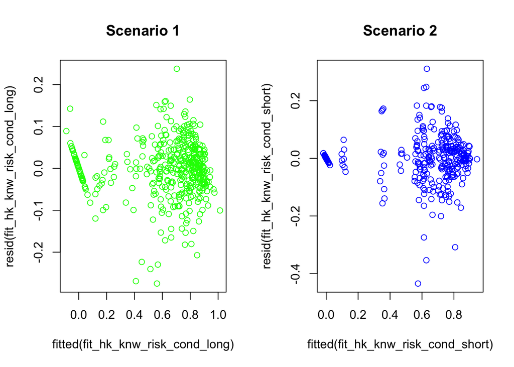

```r
par(mfrow = c(1, 2))
plot(fitted(fit_hk_knw_risk_cond_long), resid(fit_hk_knw_risk_cond_long), col = 'green', main = 'Scenario 1')
plot(fitted(fit_hk_knw_risk_cond_short), resid(fit_hk_knw_risk_cond_short), col = 'blue', main = 'Scenario 2')
```

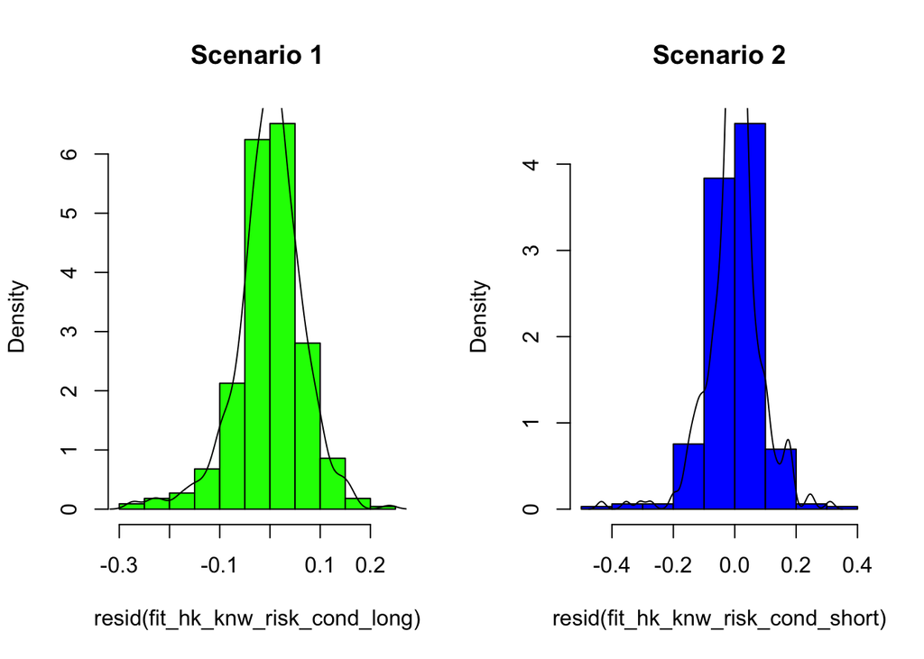

```r
par(mfrow = c(1, 2))
hist(resid(fit_hk_knw_risk_cond_long),
     main = "Scenario 1", prob=TRUE, col = 'green')
lines(density(resid(fit_hk_knw_risk_cond_long)))
hist(resid(fit_hk_knw_risk_cond_short),
     main = "Scenario 2", prob=TRUE, col = 'blue')
lines(density(resid(fit_hk_knw_risk_cond_short)))
```